# Exploratory analysis of remote sensing SIF data

D. Emin

December 20, 2018

## Introduction

HyPlant is an airborne hyperspectral sensor developed specifically for SIF retrieval over larger areas. By delivering SIF data at spatial resolution between 0.5 and 3 m, it occupies an intermediate spatial scale between ground based point spectrometer and operational and future satellite sensors. Indeed, HyPlant have been used to study the regional variability of SIF across variety of ecosystems.

HyPlant sensor have been operated on an aircraft over the Selhausen study site anually since 2014 with various scientific goals - from instrument testing to spatial SIF characterisation. It delivers high quality SIF data at least since 2016 and there is ground truth collected also at least 2016. By flying at two altitudes the HyPlant sensor delivers data at 3 and 1 meter resolution. The former resolution covers the northern half of TERENO Monitoring Observatory “Eifel/Lower Rhein valley”, while the latter higher spatial resolution is used to cover a smaller subsection - the Selhausen Study site.

At the nominal spatial resolution of 1 m2 - data from HyPlant enables analysis of the within field variability of SIF inside agricultural fields in the region. This chapter focuses on characterization of SIF data retrieved by HyPlant sensor for three consecutive years. This descriptive statistics should ensure not only about the quality of the SIF retrieval but also define typical SIF values for different crop types, inform about the specific spatial distribution of SIF inside the study area and point to probable cause of observed phenomenon.

The following analysis is made on 2016 HyPlant data only on sugar beet fields. By constraining the descriptive overview first to only one crop we can focus on regional and environmental factors. later we will expand the analysis to include all (green) crops in the region.

It includes the following sub-chapters :

- Spatial distribution of outliers
- exploratory data analysis at the nominal scale (1m)
- exploratory data analysis at the field scale (field average)
- spatial analysis in relation to soil conditions and terrace

## Data

We will use a raster stack of Selhausen study area containing all relevant layers - SIF, SIF ratio, Vegetation indicies and LAI, as well as auxilary information.

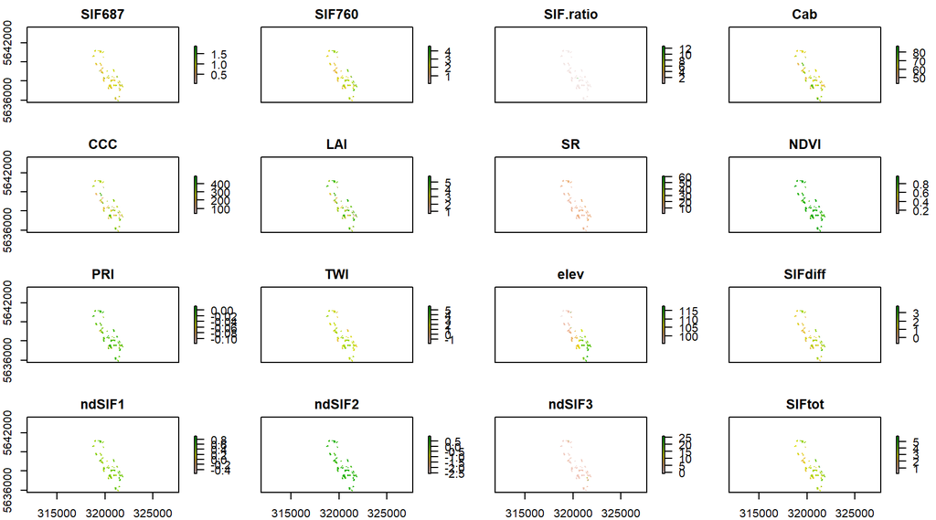

## Spatial distribution of outliers in Selhausen

The processing algorythm relies heavily on existence of bare soil pixels in the obesrvational frame. In some few cases the computation can yield negative values (normally around 0). To account for these we will first explore the raw HyPlant image and plot the distribution of SIF values.

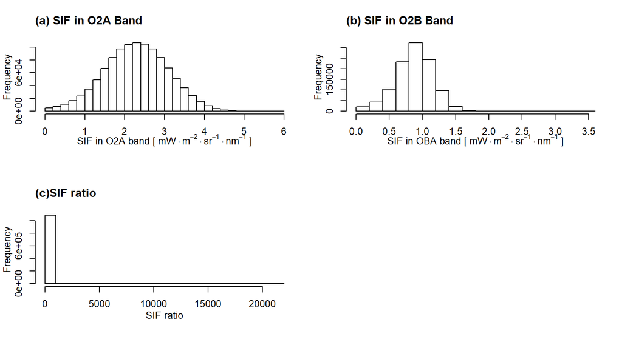

**What is the proportion of negative SIF values in our dataset? How many pixels have negative values in O2A, in O2B, in either one of both SIF bands, and in both SIF bands?**

There are a total of 22279 negative SIF (O2A) values, which amounts to 1.98 % of pixels in the entire sugar beet dataset.

There are a total of 34447 negative SIF (O2B) values, which amounts to 3.06 % of pixels in the entire sugar beet dataset.

There are a total of 42990 negative SIF values in at least one of O2A and O2B bands. This amounts to 3.82 % of pixels in the entire sugar beet dataset.

There are a total of 13736 negative SIF values in both O2A and O2B bands. This amounts to 1.22 % of pixels in the entire sugar beet dataset.

**How does exclusion of negative values affect the mean SIF estimate?**

Using all values, mean SIF760 = 2.291 [mW.s-1.nm-1.m-2].

After excluding negative values, mean SIF760 = 2.315 [mW.s-1.nm-1.m-2].

The difference is 0.024 [mW.s-1.nm-1.m-2].

We will shows the location of outliers inside sugar beet fields For easier visualisation, we will zoom-in to a smaller section of the study area and assume uniformity of the observed distribution, e.g. the process governing outlier distribution is the same across the whole study area. Now lets explore the spatial distribution of negative SIF values and SIF ratio.

### SIF ratio above 2

Since SIF ratio is calculated as SIF687/SIF760 and SIF687 is almost always smaller than SIF760 in remote sensing scenario, we expect SIF ratio values predominantly in the range between 0 and 1. To allow for the possibility of inverse magnituted of both SIF peaks, eg. red SIF being larger than far-red SIF, we will keep SIF ratio values smaller than 2. This is a conservative filter, which eliminates small percentage of values spread across a wider range.

Bellow we show the spatial distribution of SIF ratio outliers, reclasified into two classes - bellow and above the cut down value of 2.

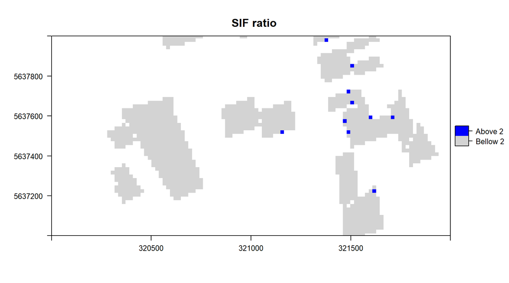

### SIF 760 negative values

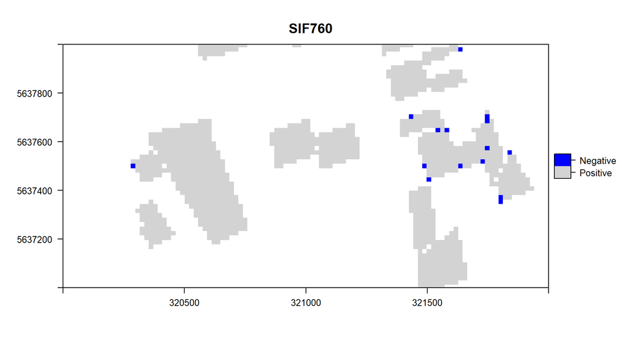

### SIF 687 negative values

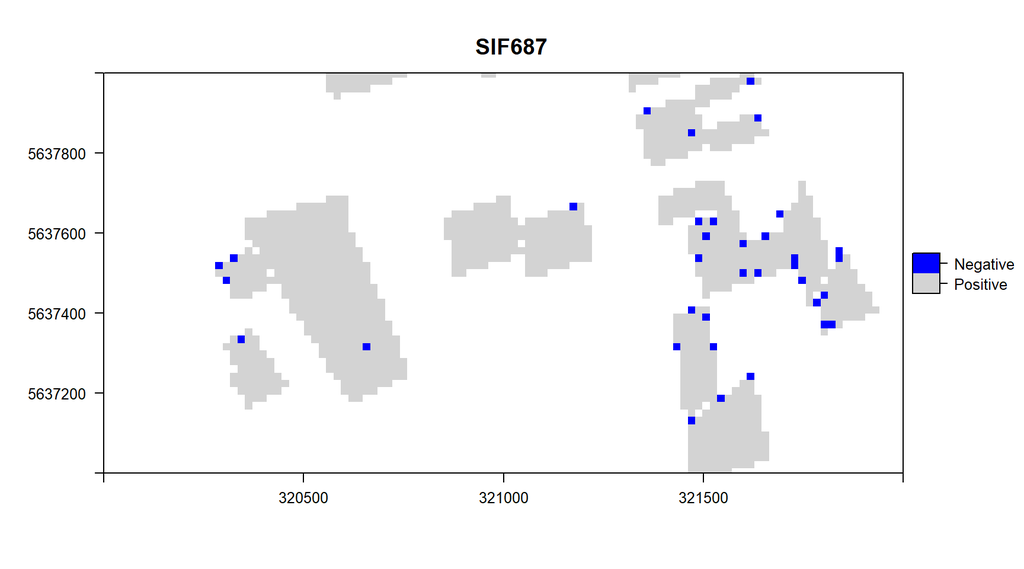

Most negative value are located long the edges of the fields. There are some exceptions at SIF687 band, specifically in smaller fields.

[output not shown]

## Full stats

### Histogram distribution

After exploring the distribution of outliers, data will be filtered to exclude negative sif values and SIF ratio values above 2.

```
##      SIF687             SIF760           SIF.ratio
##  Min.   :0.000041   Min.   :0.003927   Min.   :0.0000254
##  1st Qu.:0.712171   1st Qu.:1.795427   1st Qu.:0.2910507
##  Median :0.893657   Median :2.325384   Median :0.3774168
##  Mean   :0.880279   Mean   :2.331353   Mean   :0.4159166
##  3rd Qu.:1.065130   3rd Qu.:2.860588   3rd Qu.:0.4929729
##  Max.   :3.431148   Max.   :5.972486   Max.   :1.9998960
##       LAI              Cab             CCC              NDVI
##  Min.   :0.7179   Min.   :28.07   Min.   : 36.96   Min.   :0.1667
##  1st Qu.:2.5185   1st Qu.:60.54   1st Qu.:160.42   1st Qu.:0.9063
##  Median :4.1211   Median :64.89   Median :267.24   Median :0.9324
##  Mean   :3.7630   Mean   :65.82   Mean   :253.56   Mean   :0.9060
##  3rd Qu.:5.0125   3rd Qu.:71.14   3rd Qu.:337.73   3rd Qu.:0.9449
##  Max.   :5.9331   Max.   :91.97   Max.   :511.88   Max.   :0.9992
##     mreNDVI           reNDVI              SR                mreSR
##  Min.   :0.1113   Min.   :0.07757   Min.   :    0.948   Min.   : 1.260
##  1st Qu.:0.4917   1st Qu.:0.47583   1st Qu.:    9.382   1st Qu.: 2.935
##  Median :0.5037   Median :0.49144   Median :   12.549   Median : 3.030
##  Mean   :0.4932   Mean   :0.47866   Mean   :   11.979   Mean   : 2.962
##  3rd Qu.:0.5091   3rd Qu.:0.49991   3rd Qu.:   14.776   3rd Qu.: 3.074
##  Max.   :0.8927   Max.   :0.56775   Max.   :19900.000   Max.   :20.109
##       PRI                 elev             TWI            fieldid
##  Min.   :-0.196895   Min.   : 95.26   Min.   :-4.412   Min.   : 0.00
##  1st Qu.:-0.022111   1st Qu.: 99.59   1st Qu.: 1.852   1st Qu.:22.00
##  Median :-0.011399   Median :105.29   Median : 2.436   Median :42.00
##  Mean   :-0.017014   Mean   :105.56   Mean   : 2.335   Mean   :39.99
##  3rd Qu.:-0.004479   3rd Qu.:111.54   3rd Qu.: 2.917   3rd Qu.:58.00
##  Max.   : 0.139310   Max.   :153.96   Max.   : 6.321   Max.   :75.00
##     in.high          soilid          terid
##  Min.   :0.000   Min.   : 0.00   Min.   :1.000
##  1st Qu.:0.000   1st Qu.: 6.00   1st Qu.:2.000
##  Median :0.000   Median :14.00   Median :2.000
##  Mean   :0.345   Mean   :14.06   Mean   :2.471
##  3rd Qu.:1.000   3rd Qu.:22.00   3rd Qu.:3.000
##  Max.   :1.000   Max.   :32.00   Max.   :4.000
```

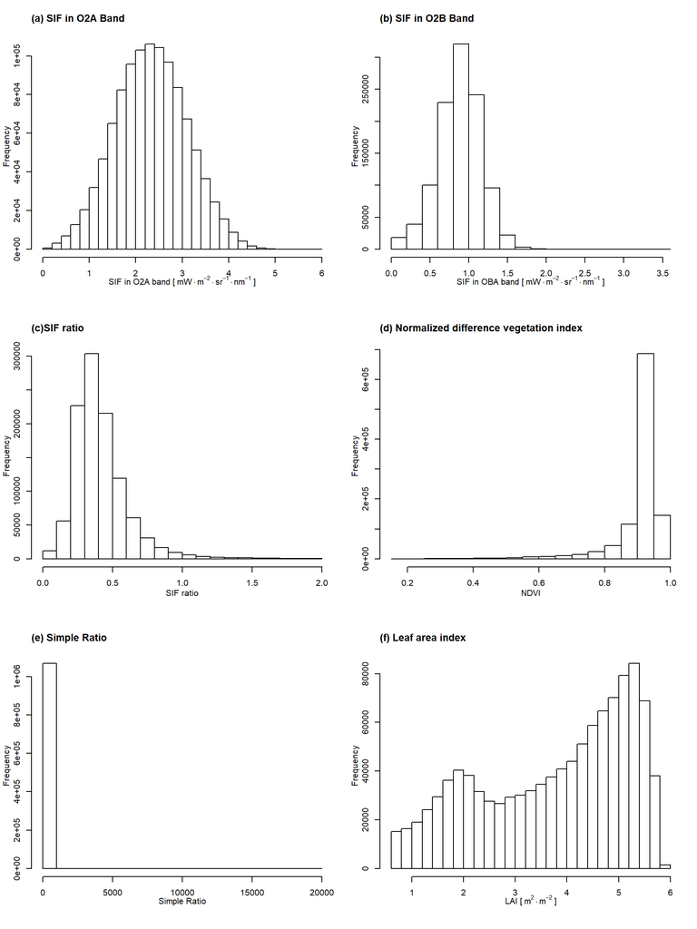

With some exception, the key variables we will use in this analysis follow a normal distribution.

### Scatterplots

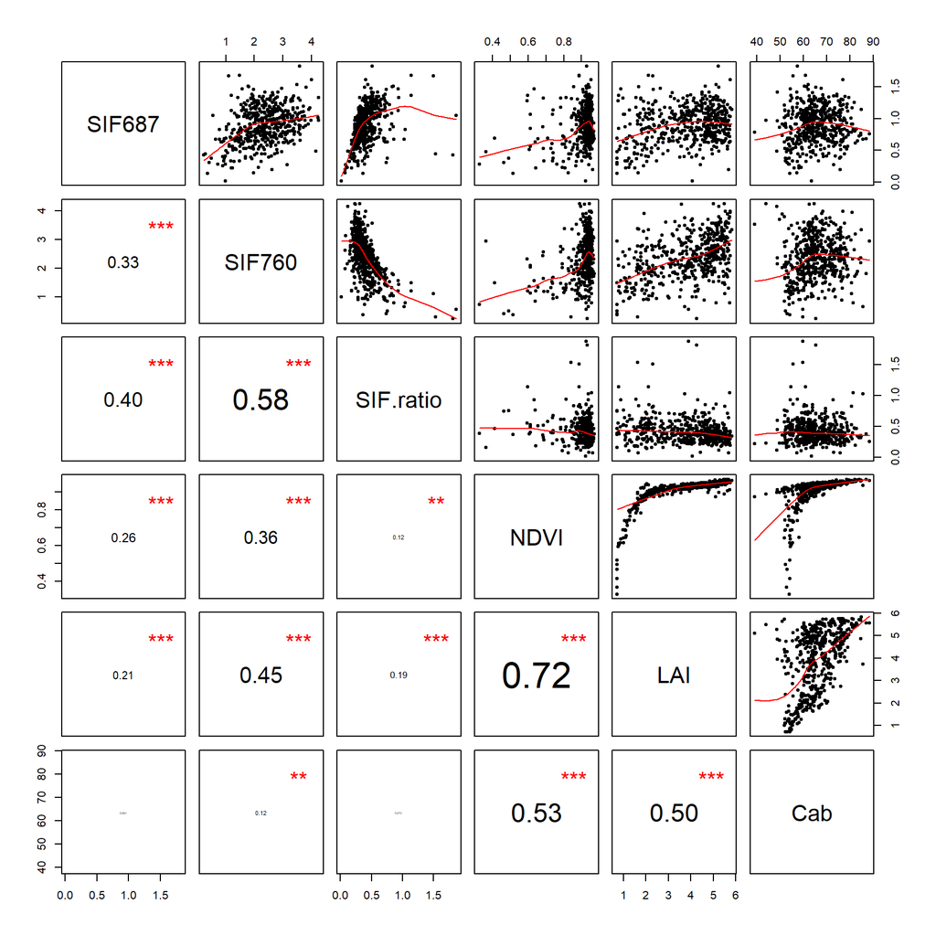

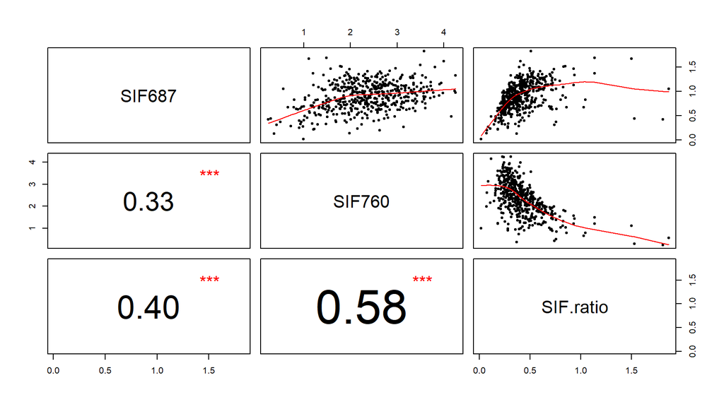

## Field stats

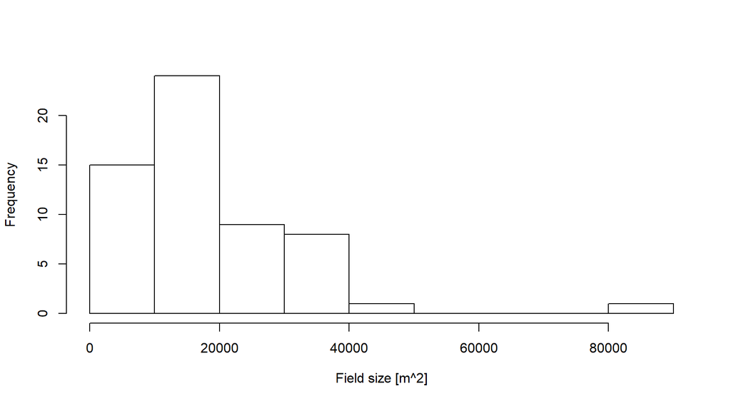

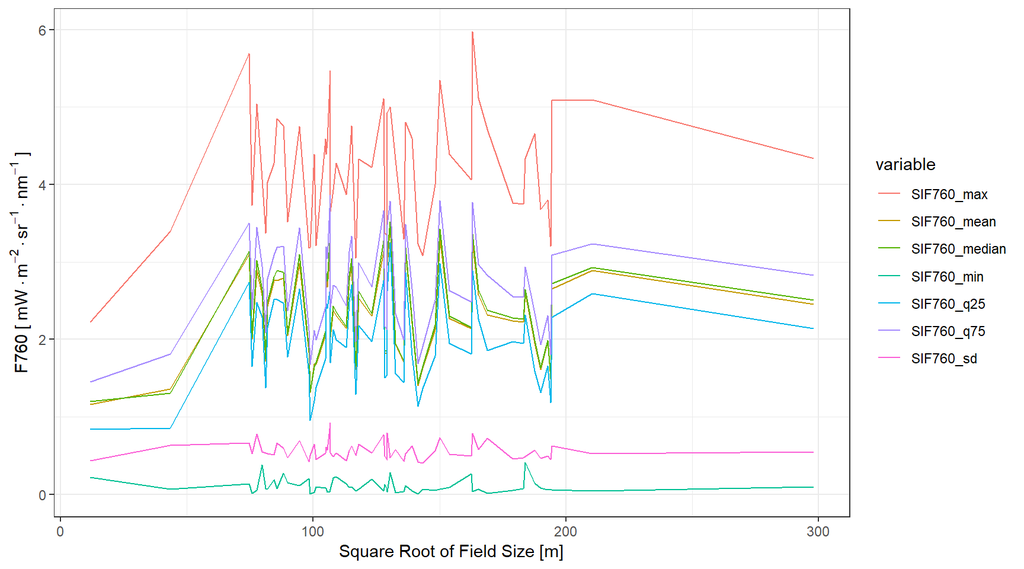

## including SOil and terrace

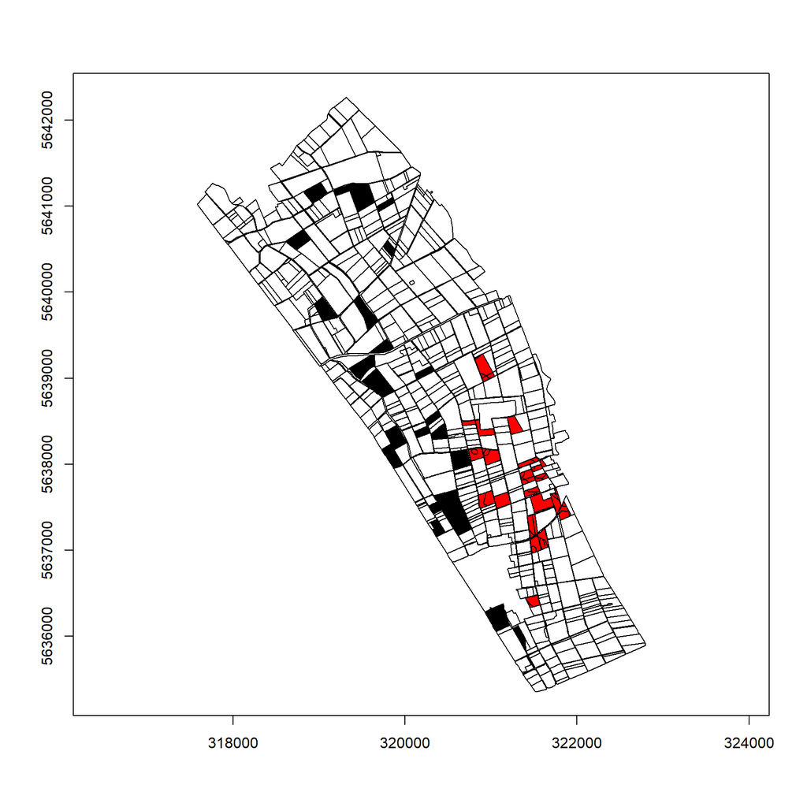

First we will divide this data frame into two - one for each pixels in low and high terrace